# Regession model perfromances

On aggregated FIFA data (all quantitative).

Nicholas Spyrison

08 Mar 2022

# Gist

# Setup

```r
require(DALEX)
require(magrittr)

## Remove a few alternative response variables
.dat_less_ys <- DALEX::fifa %>%
  dplyr::select(
    -c(`nationality`, `overall`, `potential`, `value_eur`, `wage_eur`)) %>%
  as.data.frame()

## Checking variable to aggregate
if(F)
  corrplot::corrplot(cor(.dat_less_ys),
                     iiimethod = "circle", ## geom
                     type   = "upper", ## only upper triangle
                     diag   = F, ## remove auto correlation
                     order  = "FPC", ## First principal component
                   tl.col = "black", tl.srt = 90, ## Text label color and rotation
                   tl.pos = "td")

## Aggregate some highly correlated vars
dat <- .dat_less_ys %>%
  dplyr::mutate(
    .keep = "none",
    BMI = (weight_kg+(height_cm/100L)^2L)/2L,
    age = age,
    react = movement_reactions,
    off = (attacking_finishing+skill_long_passing+attacking_volleys+
             power_long_shots+skill_curve+mentality_positioning+attacking_crossing+
             attacking_short_passing+skill_dribbling+skill_ball_control)/10L,
    def = (defending_sliding_tackle+mentality_interceptions+
             defending_standing_tackle+defending_marking+mentality_aggression)/5L,
    acc = (attacking_heading_accuracy+power_shot_power)/2L,
    mvm = (movement_sprint_speed+movement_balance+movement_acceleration+
             mentality_vision+mentality_composure+movement_agility+
             mentality_penalties+skill_fk_accuracy+power_stamina+movement_reactions)/10L,
    pwr = (power_strength+power_jumping)/2L,
    gk  = (goalkeeping_diving+goalkeeping_positioning+goalkeeping_reflexes+
             goalkeeping_handling+goalkeeping_kicking)/5L
  )
str(dat)
```

```
## 'data.frame':    5000 obs. of  9 variables:
##  $ age  : num  32 34 27 26 28 28 27 27 33 27 ...
##  $ BMI  : num  37.4 43.2 35.5 45.3 38.5 ...
##  $ react: num  95 96 92 88 90 91 86 88 89 92 ...
##  $ off  : num  92.9 87.5 87.9 19.8 85.9 88 26 62.6 83.9 84.4 ...
##  $ def  : num  36.8 35.2 33.8 22 35.6 62.8 22.6 87.8 71.8 48 ...
##  $ acc  : num  78 92 71 37 71.5 73 38.5 83.5 67 69.5 ...
##  $ mvm  : num  89.2 85.7 89.7 50.6 89.2 83.4 46.6 71.6 85 86.3 ...
##  $ pwr  : num  68 86.5 55 78 59.5 68.5 78.5 91 63 71 ...
##  $ gk   : num  10.8 11.6 11.8 87.2 9 11.2 87.8 11.6 10.4 12.4 ...
```

```r
skimr::skim(dat)
```

Data summary

| Name | dat |
| --- | --- |
| Number of rows | 5000 |
| Number of columns | 9 |
| _______________________ |  |
| Column type frequency: |  |
| numeric | 9 |
| ________________________ |  |
| Group variables | None |

**Variable type: numeric**

| skim_variable | n_missing | complete_rate | mean | sd | p0 | p25 | p50 | p75 | p100 | hist |
| --- | --- | --- | --- | --- | --- | --- | --- | --- | --- | --- |
| age | 0 | 1 | 27.17 | 4.04 | 16.00 | 24.00 | 27.00 | 30.00 | 41.00 | ▂▇▇▃▁ |
| BMI | 0 | 1 | 39.84 | 3.71 | 27.34 | 37.12 | 39.67 | 42.23 | 53.46 | ▁▅▇▃▁ |
| react | 0 | 1 | 71.28 | 5.72 | 50.00 | 68.00 | 71.00 | 75.00 | 96.00 | ▁▅▇▂▁ |
| off | 0 | 1 | 59.43 | 16.42 | 8.30 | 54.10 | 65.10 | 69.90 | 92.90 | ▁▁▂▇▁ |
| def | 0 | 1 | 55.05 | 20.24 | 11.40 | 37.00 | 63.90 | 72.20 | 90.60 | ▂▅▂▇▃ |
| acc | 0 | 1 | 63.17 | 12.09 | 23.50 | 59.00 | 65.50 | 71.00 | 92.00 | ▂▁▆▇▁ |
| mvm | 0 | 1 | 64.51 | 10.33 | 23.90 | 59.70 | 67.20 | 71.60 | 89.70 | ▁▂▃▇▁ |
| pwr | 0 | 1 | 68.97 | 9.40 | 29.50 | 63.00 | 70.00 | 75.50 | 91.00 | ▁▁▅▇▂ |
| gk | 0 | 1 | 16.49 | 18.43 | 1.00 | 9.80 | 10.80 | 12.00 | 87.80 | ▇▁▁▁▁ |

```r
## Let's get in the habit of train/test sets with something simple
X <- dat ## 9 aspects of the X's
Y <- DALEX::fifa$wage_eur
set.seed(20220308)
idx_test <- sample(1:nrow(X), size = nrow(X) / 5)
X_train  <- X[-idx_test, ]
X_test   <- X[ idx_test, ]
Y_train  <- Y[-idx_test]
Y_test   <- Y[ idx_test]
remove(X, Y)
```

# Model creation

I reckon we start with defaults and of tree-based method facilitated in cheem. We’ll try to standardize hyperparameters to something modest, though keep in mind techniques are different.

```r
## Model dependencies
require(e1071)        ## svm(), naiveBayes()
require(FNN)          ## knn.reg()
require(randomForest) ## randomForest()
require(stats)        ## glm()
require(tictoc)

## Model
tic("glm")
mod_glm <- stats::glm(Y ~ ., data.frame(X_train, Y = Y_train), family = gaussian())
toc()
```

```
## glm: 0.01 sec elapsed
```

```r
tic("svm")
mod_svm <- e1071::svm(X_train, Y_train, kernel = "linear")
toc()
```

```
## svm: 1.88 sec elapsed
```

```r
tic("naiveBayes")
mod_nb  <- e1071::naiveBayes(X_train, Y_train, laplace = 0)
toc()
```

```
## naiveBayes: 0.16 sec elapsed
```

```r
tic("knn.reg")
mod_knn <- FNN::knn.reg(train = X_train, test = X_test, y = Y_train)
toc()
```

```
## knn.reg: 0.03 sec elapsed
```

```r
tic("randomForest")
mod_rf <- randomForest::randomForest(
  x = X_train, y = Y_train,
  ntree = 63, mtry = 3, nodesize = 5) ## Same as tree-based comparison
toc()
```

```
## randomForest: 1.75 sec elapsed
```

Great we have a battery of models to compare. Let’s unify to a common interface and see if we can compare model performance

# Model perfromance (train)

Keep in mind this is the highest level peak of the model explanation pyramid and evaluated on training data.

```r
## Initialize
mod_ls <- list(
  mod_glm = mod_glm, mod_svm = mod_svm, mod_nb = mod_nb, mod_rf = mod_rf)
  #mod_knn = mod_knn, ## Non-standard use for prediction function...
nms    <- substr(names(mod_ls), 5, 99)
exp_ls <- mp_ls <- vip_ls <- list()
measures_df <- data.frame(
  matrix(NA, nrow = length(nms), ncol = 4,
         dimnames = list(nms, c("mse", "rmse", "r2", "mad")))
)

## For i in 1:length(models):
.mute <- sapply(seq_along(mod_ls), function(i){
  ## Unified explain object
  exp_ls[[i]] <<- DALEX::explain(
    model   = mod_ls[[i]],
    data    = X_train,
    y       = Y_train,
    type    = "regression",
    label   = nms[i],
    verbose = FALSE
  )
  ## Model performance
  mp_ls[[i]] <<- DALEX::model_performance(exp_ls[[i]])
  measures_df[i, ] <<- unlist(mp_ls[[i]]$measures)
  ## Variable importance
  vip_ls[[i]] <<- variable_importance(
    exp_ls[[i]], loss_function = loss_root_mean_square)
})
## Post-loop cleanup
names(exp_ls) <- paste0("exp_", nms)
names(mp_ls)  <- paste0("mp_",  nms)
names(vip_ls) <- paste0("vip_", nms)

## Display results
measures_df
```

```
##            mse  rmse      r2   mad
## glm  811339458 28484  0.3523 12880
## svm  977667234 31268  0.2195  8546
## nb  1936791466 44009 -0.5462 16931
## rf    85192402  9230  0.9320  3429
```

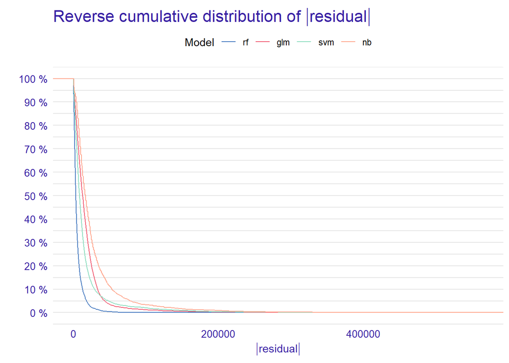

```r
plot(mp_ls)
```

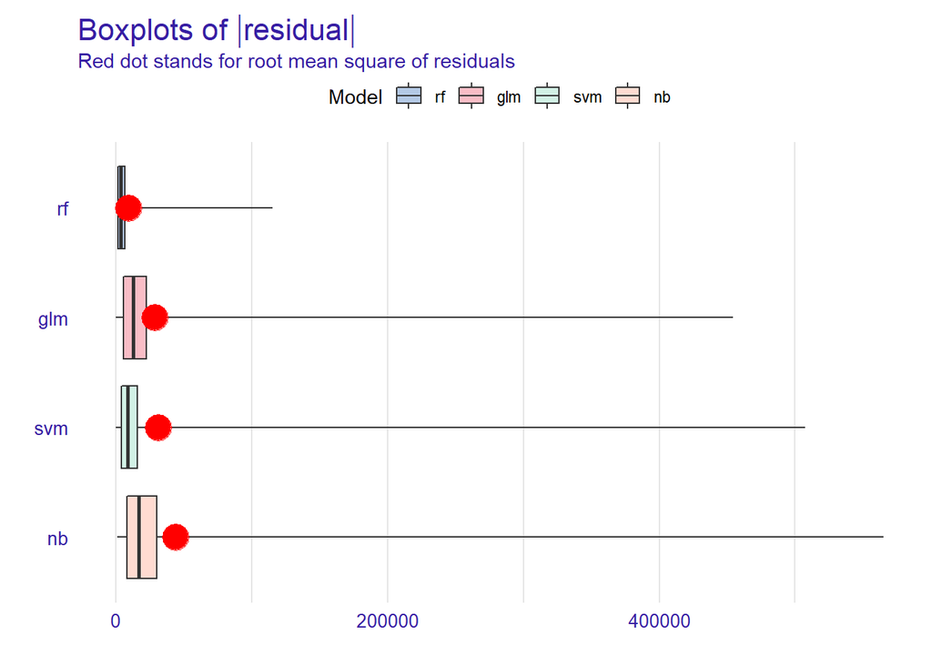

```r
plot(mp_ls, geom = "boxplot")
```

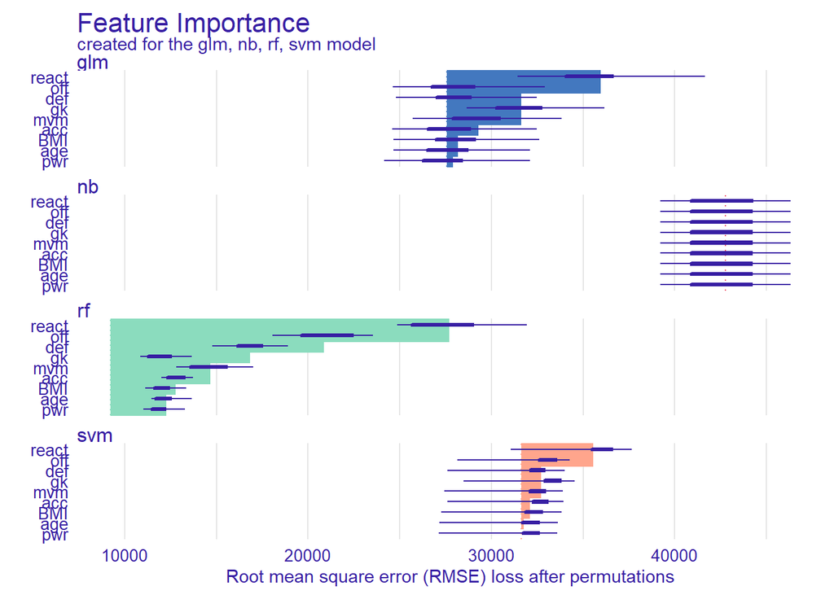

```r
plot(vip_ls)
```

The top takeaways would be: random forest uniformly performs best, naive bayes is worse (and loses variable importance), general linear models and scalar vector machines are somewhere in between. It is interesting to see that the error bars are larger than the feature importances themselves for glm and svm. This suggests that these models are extremely sensitive to this sort of permutation probing of variable importance. The above evaluates on training data. Let’s compare against the held out data.

# Model perfromance – test data

Let’s parallel these metrics for the random 20% of the data we save for testing the models.

```r
exp_ls_test <- mp_ls_test <- vip_ls_test <- list()
measures_df_test <- data.frame(
  matrix(NA, nrow = length(nms), ncol = 4,
         dimnames = list(nms, c("mse", "rmse", "r2", "mad")))
)
## For i in 1:length(models):
.mute <- sapply(seq_along(mod_ls), function(i){
    ## Unified explain object
  exp_ls_test[[i]] <<- DALEX::explain(
    model   = mod_ls[[i]],
    data    = X_test,
    y       = Y_test,
    type    = "regression",
    label   = nms[i],
    verbose = FALSE
  )
  ## Model performance
  mp_ls_test[[i]] <<- DALEX::model_performance(exp_ls_test[[i]])
  measures_df_test[i, ] <<- unlist(mp_ls_test[[i]]$measures)
  ## Variable importance
  vip_ls_test[[i]] <<- variable_importance(
    exp_ls_test[[i]], loss_function = loss_root_mean_square)
})
## Post-loop cleanup
names(exp_ls_test) <- paste0("exp_", nms)
names(mp_ls_test)  <- paste0("mp_",  nms)
names(vip_ls_test) <- paste0("vip_", nms)

## Display results
measures_df_test
```

```
##            mse  rmse      r2   mad
## glm  745600380 27306  0.3757 13828
## svm  910991445 30183  0.2372  9074
## nb  1912428840 43731 -0.6013 15994
## rf   446088533 21121  0.6265  8251
```

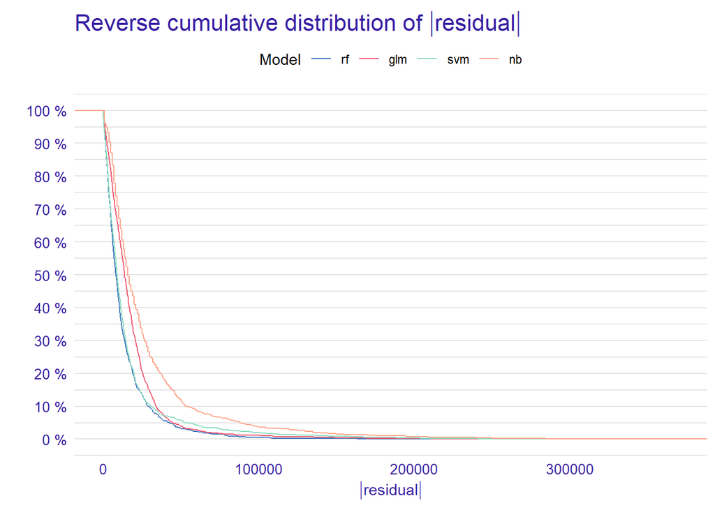

```r
plot(mp_ls_test)
```

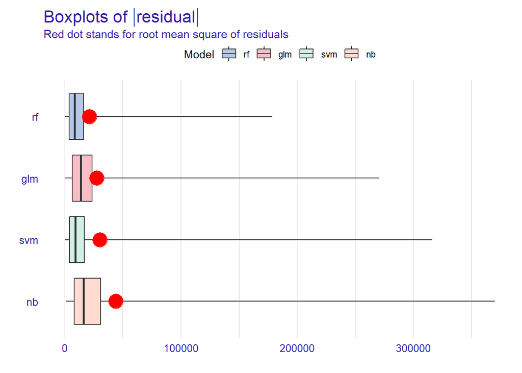

```r
plot(mp_ls_test, geom = "boxplot")
```

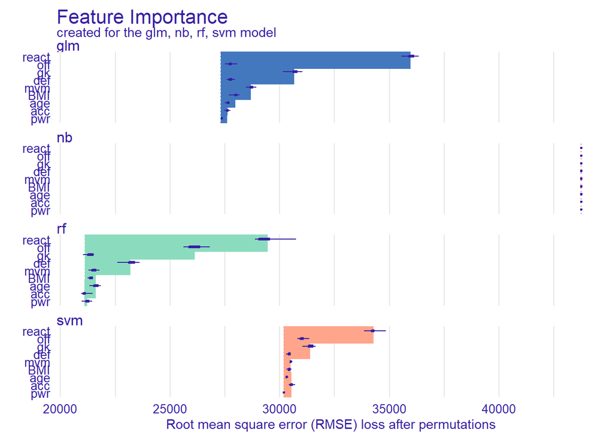

```r
plot(vip_ls_test)
```

# Session info

```r
## packages used
pkgs <- c(
  "DALEX",
  "randomForest",
  "e1071",
  "FNN",
  "stats"
)

## package & session info
```

# Related content

- https://www.analyticsvidhya.com/blog/2017/09/common-machine-learning-algorithms/#h2_15
- https://daviddalpiaz.github.io/r4sl/index.html
- https://ema.drwhy.ai/